# Data Analysis of Digital Payments and Fraud Detection

Team: TAYYAB BIN TAHIR & HARSHA SIDDAGANGAIAH

```r
library(knitr)
```

===============================================

# 1. About Data

- This is a data set of digital transactions and each transaction is clearly labeled as Fraud or Non-Fraud as a ground truth.
- The data set that we are using is not a synthetic data set instead it’s a real-world data set generated by Capital One and very much has the same kind of distribution and attributes that they work on their day-to-day basis.
- Data Set has 29 attributes which are as follows:
- Account Number
- CustomerId
- CreditLimit
- AvailableMoney
- TransactionDateTime
- TransactionAmount
- MerchantName
- AcqCountry
- MerchantCountryCode
- PosEntryMode
- PosConditionCode
- MerchantCategoryCode
- CurrentExpDate
- AccountOpenDate
- DateOfLastAddressChange
- CardCVV
- EnteredCVV
- CardLast4Digit
- TransactionType
- EchoBuffer
- CurrentBalance
- MerchantCity
- MerchantState
- MerchantZip
- CardPresent
- PosOnPremises
- RecurringAuthInd
- ExpirationDateKeyInMatch
- isFraud
- The Data set has 786363 entries, which is a fair amount of data to model frauds and non-frauds after comprehensive analysis and visualizations.
- Not all the columns are filled pre-hand, which very much represents a real-world dataset and it is important to ask questions about those column attributes to the business teams later on.
- But what can we still do to come up with a baseline and a state-of-the-art performant model on whatever we have, is the target of the project or any real-world data science pipeline.
- The nature of fraud and the non-fraud dataset is inherently imbalanced, which we can also see in the given dataset which shows only 1.6% of the time fraud has happened or reported.
- So what can we do to mitigate the fraud after doing a rigorous analysis to predict fraud in various case scenarios?

# Structure of Data:

Displaying Top 5 rows of the dataset.

```r
head(df, n = 5)
```

|  | accountNumber | customerId | creditLimit | availableMoney | transactionDateTime | transactionAmount | merchantName | acqCountry | merchantCountryCode | posEntryMode | posConditionCode | merchantCategoryCode | currentExpDate | accountOpenDate | dateOfLastAddressChange | cardCVV | enteredCVV | cardLast4Digits | transactionType | echoBuffer | currentBalance | merchantCity | merchantState | merchantZip | cardPresent | posOnPremises | recurringAuthInd | expirationDateKeyInMatch | isFraud |
| --- | --- | --- | --- | --- | --- | --- | --- | --- | --- | --- | --- | --- | --- | --- | --- | --- | --- | --- | --- | --- | --- | --- | --- | --- | --- | --- | --- | --- | --- |
| 1 | 737265056 | 737265056 | 5000 | 5000 | 2016-08-13T14:27:32 | 98.55 | Uber | US | US | 02 | 01 | rideshare | 06/2023 | 2015-03-14 | 2015-03-14 | 414 | 414 | 1803 | PURCHASE |  | 0 |  |  |  | FALSE |  |  | FALSE | FALSE |
| 2 | 737265056 | 737265056 | 5000 | 5000 | 2016-10-11T05:05:54 | 74.51 | AMC #191138 | US | US | 09 | 01 | entertainment | 02/2024 | 2015-03-14 | 2015-03-14 | 486 | 486 | 767 | PURCHASE |  | 0 |  |  |  | TRUE |  |  | FALSE | FALSE |
| 3 | 737265056 | 737265056 | 5000 | 5000 | 2016-11-08T09:18:39 | 7.47 | Play Store | US | US | 09 | 01 | mobileapps | 08/2025 | 2015-03-14 | 2015-03-14 | 486 | 486 | 767 | PURCHASE |  | 0 |  |  |  | FALSE |  |  | FALSE | FALSE |
| 4 | 737265056 | 737265056 | 5000 | 5000 | 2016-12-10T02:14:50 | 7.47 | Play Store | US | US | 09 | 01 | mobileapps | 08/2025 | 2015-03-14 | 2015-03-14 | 486 | 486 | 767 | PURCHASE |  | 0 |  |  |  | FALSE |  |  | FALSE | FALSE |
| 5 | 830329091 | 830329091 | 5000 | 5000 | 2016-03-24T21:04:46 | 71.18 | Tim Hortons #947751 | US | US | 02 | 01 | fastfood | 10/2029 | 2015-08-06 | 2015-08-06 | 885 | 885 | 3143 | PURCHASE |  | 0 |  |  |  | TRUE |  |  | FALSE | FALSE |

Description and Basic Summary of the Dataset, which explains the type of columns present, their datatypes, total number of entries in that column

```r
summary(df)
```

```
##  accountNumber       customerId         creditLimit
##  Length:786363      Length:786363      Min.   :  250
##  Class :character   Class :character   1st Qu.: 5000
##  Mode  :character   Mode  :character   Median : 7500
##                                        Mean   :10759
##                                        3rd Qu.:15000
##                                        Max.   :50000
##  availableMoney  transactionDateTime transactionAmount
##  Min.   :-1006   Length:786363       Min.   :   0.00
##  1st Qu.: 1077   Class :character    1st Qu.:  33.65
##  Median : 3185   Mode  :character    Median :  87.90
##  Mean   : 6251                       Mean   : 136.99
##  3rd Qu.: 7500                       3rd Qu.: 191.48
##  Max.   :50000                       Max.   :2011.54
##  merchantName        acqCountry        merchantCountryCode
##  Length:786363      Length:786363      Length:786363
##  Class :character   Class :character   Class :character
##  Mode  :character   Mode  :character   Mode  :character
##
##
##
##  posEntryMode       posConditionCode   merchantCategoryCode
##  Length:786363      Length:786363      Length:786363
##  Class :character   Class :character   Class :character
##  Mode  :character   Mode  :character   Mode  :character
##
##
##
##  currentExpDate     accountOpenDate
##  Length:786363      Length:786363
##  Class :character   Class :character
##  Mode  :character   Mode  :character
##
##
##
##  dateOfLastAddressChange   cardCVV
##  Length:786363           Length:786363
##  Class :character        Class :character
##  Mode  :character        Mode  :character
##
```

[output cut: 22 more lines]

```
##
##  posOnPremises      recurringAuthInd
##  Length:786363      Length:786363
##  Class :character   Class :character
##  Mode  :character   Mode  :character
##
##
##
##  expirationDateKeyInMatch  isFraud
##  Mode :logical            Mode :logical
##  FALSE:785320             FALSE:773946
##  TRUE :1043               TRUE :12417
##
##
##
```

Displaying All the columns in the data at a glance. Columns Names:

```r
colnames(df)
```

```
##  [1] "accountNumber"            "customerId"
##  [3] "creditLimit"              "availableMoney"
##  [5] "transactionDateTime"      "transactionAmount"
##  [7] "merchantName"             "acqCountry"
##  [9] "merchantCountryCode"      "posEntryMode"
## [11] "posConditionCode"         "merchantCategoryCode"
## [13] "currentExpDate"           "accountOpenDate"
## [15] "dateOfLastAddressChange"  "cardCVV"
## [17] "enteredCVV"               "cardLast4Digits"
## [19] "transactionType"          "echoBuffer"
## [21] "currentBalance"           "merchantCity"
## [23] "merchantState"            "merchantZip"
## [25] "cardPresent"              "posOnPremises"
## [27] "recurringAuthInd"         "expirationDateKeyInMatch"
## [29] "isFraud"
```

Dimension of dataset:

```r
dim(df)
```

```
## [1] 786363     29
```

Number of Records = 786363 Number of Attributes/Columns = 29

Null values in data:

- Which columns have NA values and further we’ll fill it with appropriate numbers in each column, after the analysis.

```r
df[df == ""] <- NA
colSums(is.na(df))
```

```
##            accountNumber               customerId
##                        0                        0
##              creditLimit           availableMoney
##                        0                        0
##      transactionDateTime        transactionAmount
##                        0                        0
##             merchantName               acqCountry
##                        0                     4562
##      merchantCountryCode             posEntryMode
##                      724                     4054
##         posConditionCode     merchantCategoryCode
##                      409                        0
##           currentExpDate          accountOpenDate
##                        0                        0
##  dateOfLastAddressChange                  cardCVV
##                        0                        0
##               enteredCVV          cardLast4Digits
##                        0                        0
##          transactionType               echoBuffer
##                      698                   786363
##           currentBalance             merchantCity
##                        0                   786363
##            merchantState              merchantZip
##                   786363                   786363
##              cardPresent            posOnPremises
##                        0                   786363
##         recurringAuthInd expirationDateKeyInMatch
##                   786363                        0
##                  isFraud
##                        0
```

Unique values in data:

- Unique values in each attribute also helps in exploring the structure of the dataset.
- When an attribute has less number of Unique Values it is always a good criteria to look at them keenly to know more about the structure as a whole and how the other attributes are behaving around these small buckets.

```r
require(dplyr)
sapply(df, n_distinct)
```

```
##            accountNumber               customerId
##                     5000                     5000
##              creditLimit           availableMoney
##                       10                   521916
##      transactionDateTime        transactionAmount
##                   776637                    66038
##             merchantName               acqCountry
##                     2490                        5
##      merchantCountryCode             posEntryMode
##                        5                        6
##         posConditionCode     merchantCategoryCode
##                        4                       19
##           currentExpDate          accountOpenDate
##                      165                     1820
##  dateOfLastAddressChange                  cardCVV
##                     2184                      899
##               enteredCVV          cardLast4Digits
##                      976                     5246
##          transactionType               echoBuffer
##                        4                        1
##           currentBalance             merchantCity
##                   487318                        1
##            merchantState              merchantZip
##                        1                        1
##              cardPresent            posOnPremises
##                        2                        1
##         recurringAuthInd expirationDateKeyInMatch
##                        1                        2
##                  isFraud
##                        2
```

Response attribute “isFraud” :

- The most important attribute of the given dataset, which can be a label in a classification problem.

```r
require(dplyr)
dplyr::count(df, isFraud, sort = TRUE)
```

| isFraud | n |
| --- | --- |
| FALSE | 773946 |
| TRUE | 12417 |

isFraud attribute has 1.6% True Values.

# 2. Questions

- Evaluating the distribution of the various attributes in the dataset, whether they are numerical or categorical, mapping into optimal buckets.
- What types of Merchants exist in the dataset, online, offline, etc., and which merchants should be prioritized from a business point of view.
- What kind of transactions is happening in the given data, and which is the dominant type?
- If the card Present during the transaction has any causation or correlation with the fraud.
- Deep Dive into the numerical attributes of the card, which may have a direct impact and can be of high importance, e.g., credit card limit, available balance, etc.
- The important Merchant names where most of the fraud happens is a must question to address.
- Which customers are experiencing most fraud cases and where are they doing most of their transactions, to take important actions.
- Correlation between numerical attributes of the credit card, important to question the causation with fraud in the end.
- The optimal way to remove empty columns (either consult the business teams or perform whatever is in hand and later on deep dive into the business domain that if those features are important from a business perspective and how can we do data acquisition for such attributes.)
- Feature Engineering and Data Transformation to add more sense to data and may enhance modeling performance.
- Analysis to see how many transactions can be labeled as Duplicate Transactions as it can be Multi-Swiped Transactions which may have a high chance of fraud.
- What are the important attributes, to identify the duplicate transactions and check the percentage of these transactions?
- Identifying the outliers in the attributes and optimal reasoning to remove those for better generalization, may help in modeling distribution to not be highly skewed.
- How different time slots of the day can be generated from the existing Date Time attribute and how these slots can help enhance the performance.
- Why does removing unique identifiers make sense in data modeling, eg., IDs of customers, etc.?
- The optimal way to fill the null values, based on the distribution of the data or mean/median/mode.
- Treating the highly imbalanced dataset with Under-sampling and over-sampling
- Baseline Modeling: Logistic Regression, K-Nearest Neighbor
- Evaluating results on various metrics: Accuracy, F1 Score, Precision, Recall, Confidence Interval, Significance of P-value, ROC, and AUC curves.
- Interpretability of features: Decision Tree
- Feature Importance: Random Forest
- High Performant Model: XGBoost
- Principal Component Analysis for addressing the predictability and how much variance can be explained with a few PCA components.
- Summary of Results and Impact.
- Future Deep Diving in Real-world scenarios.

# 3. Data Visualization and Answers to Questions:

### This and follwing sections will try to answer the questions mentioned above with various graphs that may include: Plots, Histograms, Box Plots, Correlation Matrix and Hypothesis about the Structure of Data.

- Converting True/False Booleans as 0s and 1s. As numerical values are meaningful to deal with.

```r
df$isFraud <- as.integer(df$isFraud)
df$cardPresent <- as.integer(df$cardPresent)
df$expirationDateKeyInMatch <- as.integer(df$expirationDateKeyInMatch)
```

### Buckets/Unique Values in Credit Card Limit Column are shown below:

- Most of the Credit Cards have 5000 as their limit amount, on second number it is 15000.
- Interestingly, credit cards with 50,000 limit also exists in the dataset*

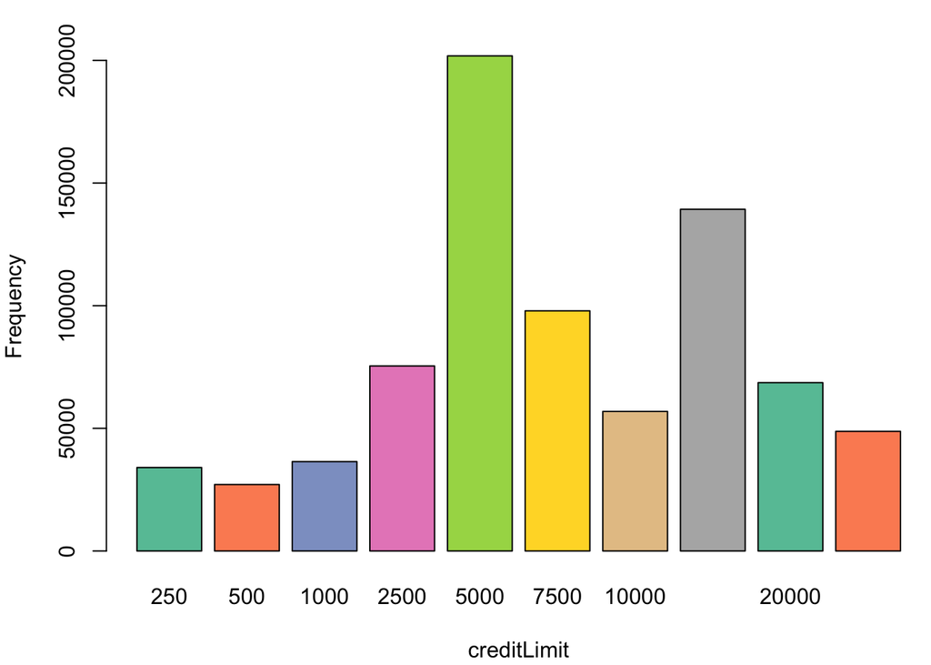

```r
library(RColorBrewer)
e = count(df, creditLimit)
e <- e[complete.cases(e), ]
coul <- brewer.pal(8, "Set2")
par(mar  = c(4.1, 4 ,2.1 ,0))
barplot(height= e$n, names= e$creditLimit, xlab = 'creditLimit' , ylab = 'Frequency', col=coul)
```

### Question:

### 4 Types of Merchant Country Code exists in the dataset, where US is a dominant entity as shown.

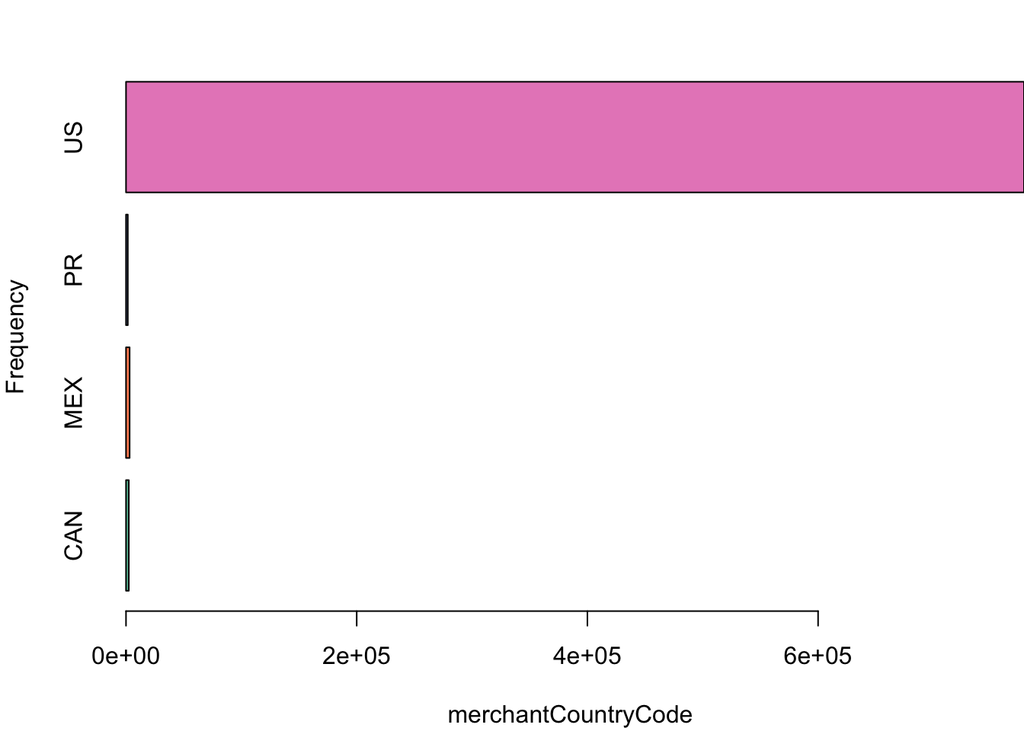

```r
library(RColorBrewer)
coul <- brewer.pal(8, "Set2")
e = count(df, merchantCountryCode)
e <- e[complete.cases(e), ]
par(mar  = c(4.1, 4 ,2.1 ,0))
barplot(height= e$n, names= e$merchantCountryCode, xlab = 'merchantCountryCode' , ylab = 'Frequency', col=coul, horiz = TRUE)
```

### 5 POS Entery Mode exists where “05”, “09”, and “02” covers most of the values.

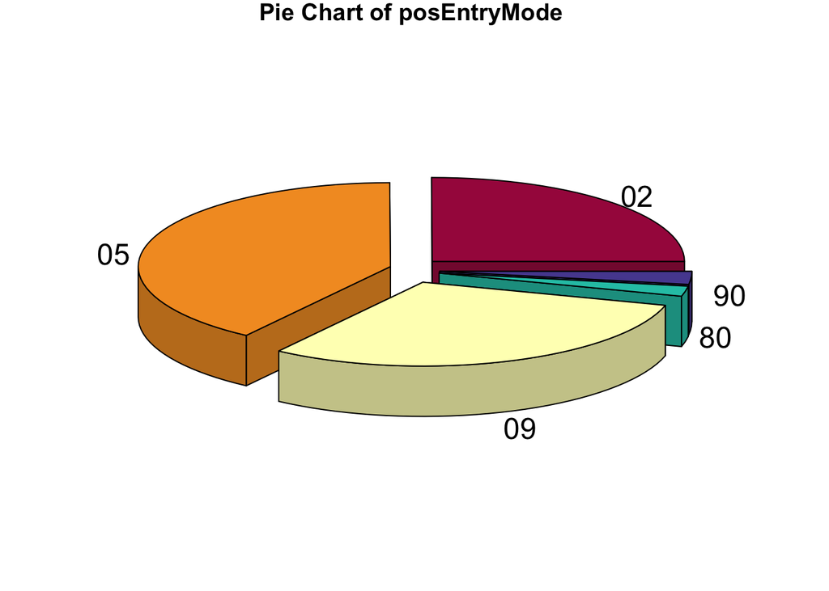

```r
library(plotrix)
e = count(df, posEntryMode)
e <- e[complete.cases(e), ]
pie3D(e$n,labels = e$posEntryMode,explode = 0.1, main = "Pie Chart of posEntryMode ", mar = rep(1, 4),col = hcl.colors(length(e$n), "Spectral"))
```

### 3 POS Condition Mode exists where “01” is dominant among all.

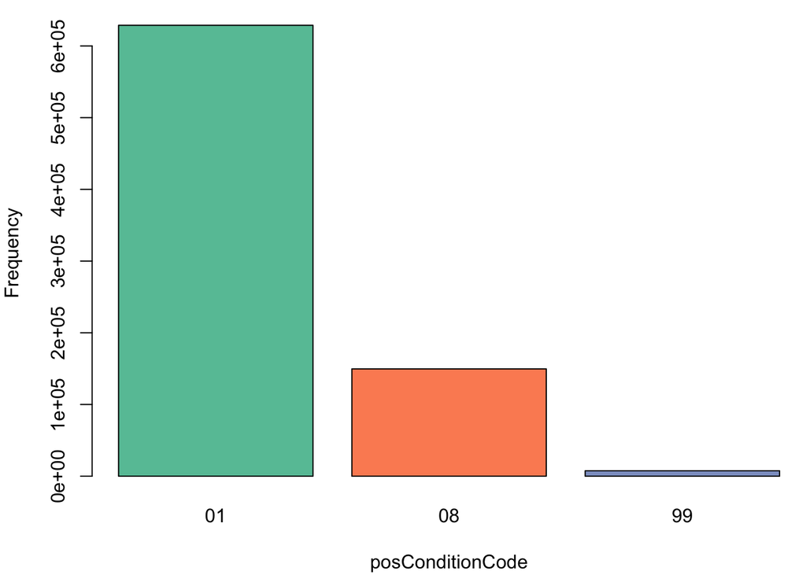

```r
library(RColorBrewer)
coul <- brewer.pal(8, "Set2")
e = count(df, posConditionCode)
e <- e[complete.cases(e), ]
par(mar  = c(4.1, 4 ,1.1 ,0))
barplot(height= e$n, names= e$posConditionCode, xlab = 'posConditionCode' , ylab = 'Frequency', col=coul)
```

### Question:

### There are 3 Types of Transaction types:

- 1. Purchase
- 2. Reversal
- 3. Address Verification
- Most values lie among Purchase Type of transaction. But it is necessary to explore the other two types too, to analyze what is happening in those transactions.

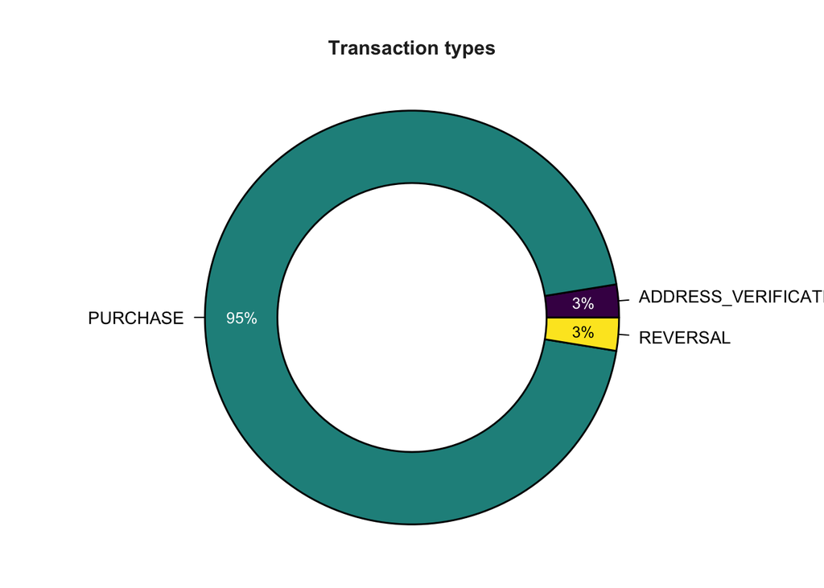

```
## >>> Suggestions
## PieChart(transactionType, hole=0)  # traditional pie chart
## PieChart(transactionType, values="%")  # display %'s on the chart
## PieChart(transactionType)  # bar chart
## Plot(transactionType)  # bubble plot
## Plot(transactionType, values="count")  # lollipop plot
##
## --- transactionType ---
##
##        transactinTyp    Count   Prop
## -------------------------------------
## ADDRESS_VERIFICATION    20169   0.026
##             PURCHASE   745193   0.948
##             REVERSAL    20303   0.026
## -------------------------------------
##                Total   785665   1.000
##
## Chi-squared test of null hypothesis of equal probabilities
##   Chisq = 1337879.797, df = 2, p-value = 0.000
```

```r
library(lessR)
merchant_with_fraud1 = subset(df, transactionType != is.na(transactionType), select = transactionType)
cols <- hcl.colors(length(unique(merchant_with_fraud1$transactionType)), "Zissou 1")
PieChart(transactionType,data = merchant_with_fraud1,values="%",
         fill = "viridis",
         main = "Transaction types",
         color = "black",
         lwd = 1.5,
         values_color = c(rep("white", 2), 1),
         values_size = 0.8)
```

- If card is Present during the transaction, it plays an important role and dataset is fairly distributed among the two values as True/False

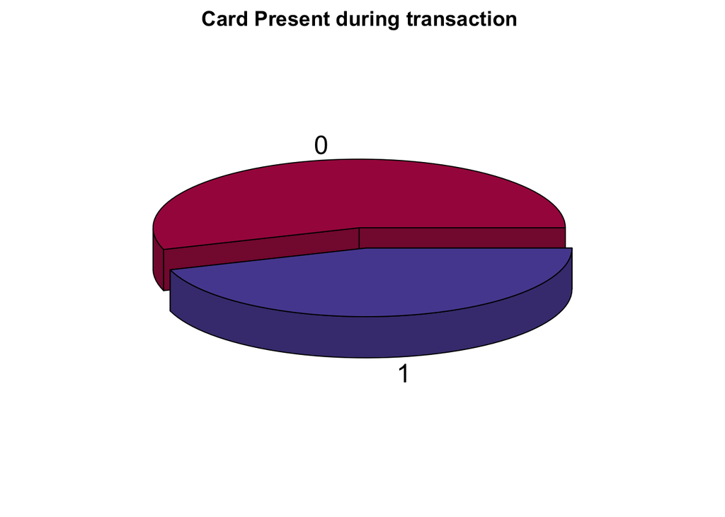

```r
library(plotrix)
e = count(df, cardPresent)
e <- e[complete.cases(e), ]
pie3D(e$n,labels = e$cardPresent,explode = 0.1, main = "Card Present during transaction ", mar = rep(1.75, 4),col = hcl.colors(length(e$n), "Spectral"))
```

- Expiration Date Key In Match is highly skewed to 0 value

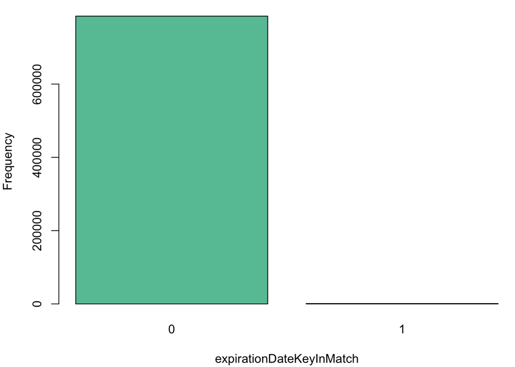

```r
library(RColorBrewer)
coul <- brewer.pal(8, "Set2")
e = count(df, expirationDateKeyInMatch)
e <- e[complete.cases(e), ]
par(mar  = c(4.1, 4 ,1.1 ,0))
barplot(height= e$n, names= e$expirationDateKeyInMatch, xlab = 'expirationDateKeyInMatch' , ylab = 'Frequency', col=coul)
```

- Count of expirationDateKeyInMatch

```r
count(df, expirationDateKeyInMatch)
```

| expirationDateKeyInMatch | n |
| --- | --- |
| 0 | 785320 |
| 1 | 1043 |

### Question:

### List of top merchants

- Here we can clearly see which are the Top Merchants:
- To know more about the transaction data set it is important to know the Top Merchants where most of the Transactions happen. It helps in Optimizing the metrics and to prioritize the business and data strategies accordingly.
- 1. Uber
- 2. Lyft
- 3. oldnavy.com
- 4. staples.com
- 5. alibaba.com
- 6. apple.com
- 7. walmart.com
- 8. cheapfast.com
- 9. ebay.com
- 10. target.com

```r
important_merchants = count(df, merchantName)
important_merchants <- filter(important_merchants, n > 10000)
arrange(important_merchants, -n)
```

| merchantName | n |
| --- | --- |
| Uber | 25613 |
| Lyft | 25523 |
| oldnavy.com | 16992 |
| staples.com | 16980 |
| alibaba.com | 16959 |
| apple.com | 16898 |
| walmart.com | 16873 |
| cheapfast.com | 16858 |
| ebay.com | 16842 |
| target.com | 16813 |

[output cut: 4 more lines]

### Question:

### Top Transaction Types, in terms of their name, to understand the behavior of data.

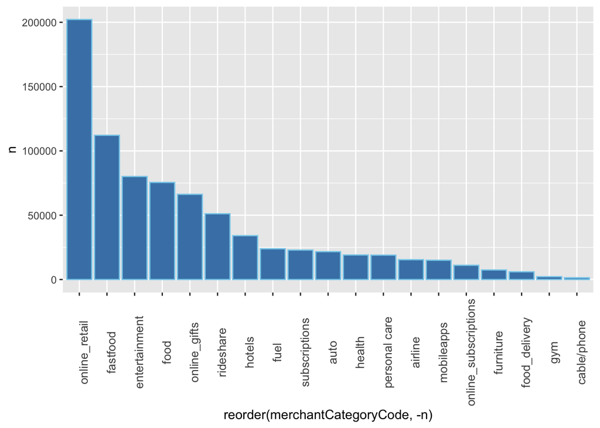

```r
library("ggplot2")
e = count(df, merchantCategoryCode)
e <- e[complete.cases(e), ]
ggplot(e, aes(reorder(merchantCategoryCode, -n), n)) +
  geom_bar(stat = "identity",color='skyblue',fill='steelblue')+
  theme(axis.text.x = element_text(angle = 90, size = 10))
```

### Question:

### Let’s explore Numerical Valued Attributes in Credit Card Transactions these attributes hold high importance because they directly impact the response variable isFraud.

```r
df_num = df[ , c("creditLimit", "availableMoney","transactionAmount", "currentBalance")]
head(df_num, n = 5)
```

|  | creditLimit | availableMoney | transactionAmount | currentBalance |
| --- | --- | --- | --- | --- |
| 1 | 5000 | 5000 | 98.55 | 0 |
| 2 | 5000 | 5000 | 74.51 | 0 |
| 3 | 5000 | 5000 | 7.47 | 0 |
| 4 | 5000 | 5000 | 7.47 | 0 |
| 5 | 5000 | 5000 | 71.18 | 0 |

- Separatelty describing these numerical attributes to get the essence of data and its distribution.

### Important Note:

- Here we can see Available Money can also be Negative, which is -1005.63 as minimum value*

```r
summary(df_num)
```

```
##   creditLimit    availableMoney  transactionAmount
##  Min.   :  250   Min.   :-1006   Min.   :   0.00
##  1st Qu.: 5000   1st Qu.: 1077   1st Qu.:  33.65
##  Median : 7500   Median : 3185   Median :  87.90
##  Mean   :10759   Mean   : 6251   Mean   : 136.99
##  3rd Qu.:15000   3rd Qu.: 7500   3rd Qu.: 191.48
##  Max.   :50000   Max.   :50000   Max.   :2011.54
##  currentBalance
##  Min.   :    0.0
##  1st Qu.:  689.9
##  Median : 2451.8
##  Mean   : 4508.7
##  3rd Qu.: 5291.1
##  Max.   :47498.8
```

- Through analysis it can be seen that most of the Credit limits are under 10,000.
- But some goes till 50,000.
- While data Modelling this information can be really useful.

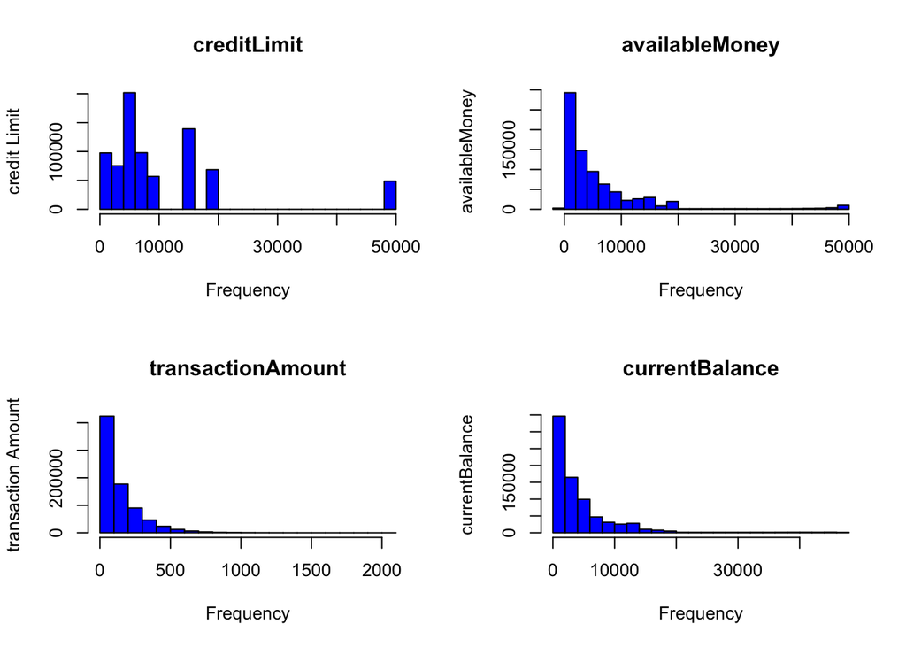

```r
par(mfrow=c(2,2))
hist(df[ , c("creditLimit")], main="creditLimit", xlab="Frequency", ylab="credit Limit", col = "blue")
hist(df[ , c("availableMoney")], main="availableMoney", xlab="Frequency", ylab="availableMoney", col = "blue")
hist(df[ , c("transactionAmount")], main="transactionAmount", xlab="Frequency", ylab="transaction Amount", col = "blue")
hist(df[ , c("currentBalance")], main="currentBalance", xlab="Frequency", ylab="currentBalance", col = "blue")
```

- Available Money mostly lie under the buckets of less than 10,000. It is Right Skewed, which actually makes sense in the amount figures.
- Interestingly, Transaction amount mostly falls under 500 and is Right Skewed.

### Question:

### Box Plots help analyzing the data distribution and beautifully caters Outliers in the datasets and the skewness.

- It can explain the quantiles of the distribution.
- It shows how these Numerical Atrributes are Right Skewed

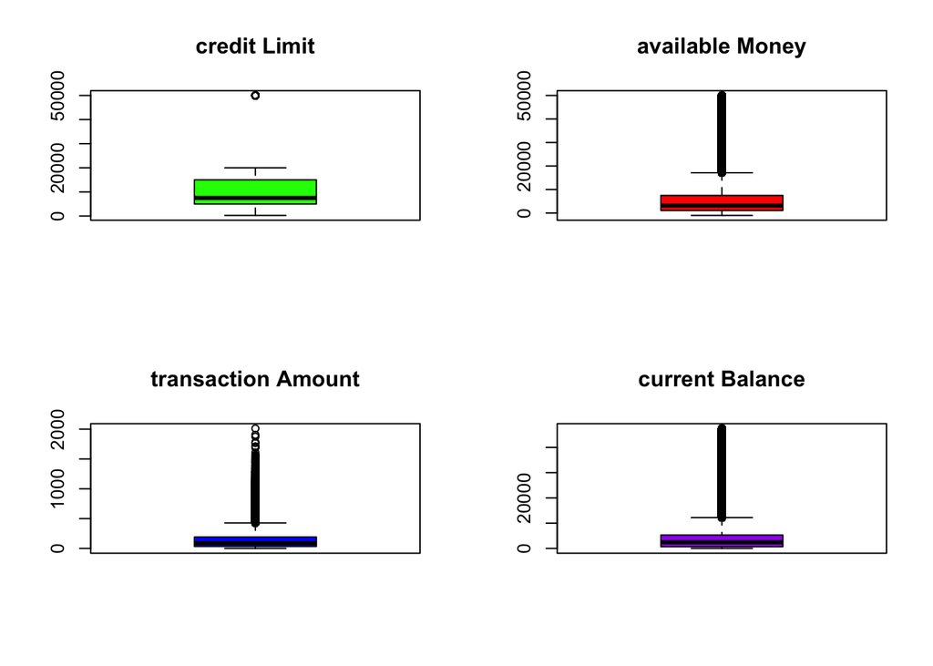

```r
par(mfrow=c(2,2))
boxplot(df_num[ , c("creditLimit")], col = "green", main="credit Limit")
boxplot(df_num[ , c("availableMoney")], col = "red", main="available Money")
boxplot(df_num[ , c("transactionAmount")], col = "blue", main="transaction Amount")
boxplot(df_num[ , c("currentBalance")], col = "purple", main="current Balance")
```

### Most Fradulant Merchant Types

- Merchant Type with highest fraud transaction

```r
merchant_with_fraud = subset(df, isFraud == '1', select = merchantCategoryCode)
head(merchant_with_fraud, n = 10)
```

|  | merchantCategoryCode |
| --- | --- |
| 695 | health |
| 972 | online_retail |
| 1073 | health |
| 1114 | online_retail |
| 1322 | online_retail |
| 1346 | rideshare |
| 1347 | rideshare |
| 1368 | online_retail |
| 1417 | online_retail |
| 1624 | online_retail |

### Question:

### Top 3 Merchant Categories are:

- 1. Online Retail
- 2. Online Gifts
- 3. Ride Share

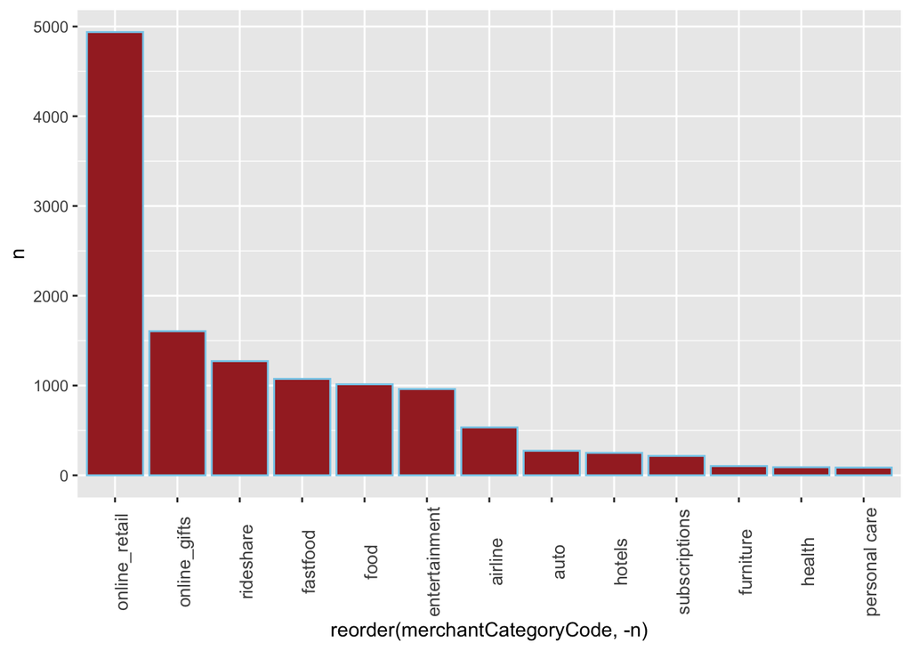

```r
library("ggplot2")
e = count(merchant_with_fraud, merchantCategoryCode)
e <- e[complete.cases(e), ]
ggplot(e, aes(reorder(merchantCategoryCode, -n), n)) +
  geom_bar(stat = "identity",color='skyblue',fill='brown')+
  theme(axis.text.x = element_text(angle = 90, size = 10))
```

### Question:

### The Merchant Names where most Fraud happens:

### Top 5 are:

- 1. Lyft
- 2. ebay.com
- 3. Fresh Flowers
- 4. Uber
- 5. walmart.com

```r
merchant_name__with_fraud = subset(df, isFraud == '1', select = merchantName)
important_merchants = count(merchant_name__with_fraud, merchantName)
important_merchants = filter(important_merchants, n > 300)
arrange(important_merchants, -n)
```

| merchantName | n |
| --- | --- |
| Lyft | 760 |
| ebay.com | 639 |
| Fresh Flowers | 553 |
| Uber | 512 |
| walmart.com | 446 |
| cheapfast.com | 442 |
| sears.com | 422 |
| oldnavy.com | 401 |
| staples.com | 399 |
| alibaba.com | 383 |

[output cut: 5 more lines]

### Question:

### The Customers and account IDs which get most frauds can also be analyzed through dataset.

### Top 3 Account IDs are:

- 1. 380680241
- 2. 782081187
- 3. 246251253

```r
accountNumber_with_fraud = subset(df, isFraud == '1', select = accountNumber)
important_merchants = count(accountNumber_with_fraud, accountNumber)
important_merchants = filter(important_merchants, n > 200)
arrange(important_merchants, -n)
```

| accountNumber | n |
| --- | --- |
| 380680241 | 783 |
| 782081187 | 307 |
| 246251253 | 278 |
| 700725639 | 272 |
| 472288969 | 266 |
| 208319653 | 211 |
| 419709514 | 207 |

### Important Note: Account IDs and Customer IDs are the same.

```r
customers_with_fraud = subset(df, isFraud == '1', select = customerId)
important_merchants = count(customers_with_fraud, customerId)
important_merchants = filter(important_merchants, n > 200)
arrange(important_merchants, -n)
```

| customerId | n |
| --- | --- |
| 380680241 | 783 |
| 782081187 | 307 |
| 246251253 | 278 |
| 700725639 | 272 |
| 472288969 | 266 |
| 208319653 | 211 |
| 419709514 | 207 |

### Correlation Matrix between Numerical Attributes

- Tells important information about the inter-correlation.

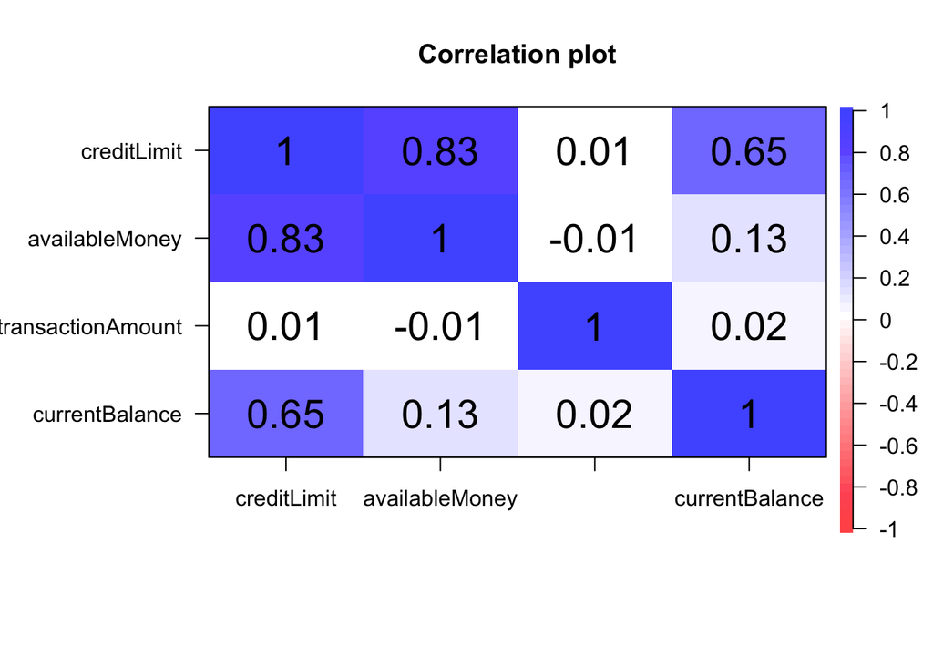

```r
library(psych)
corPlot(df_num, cex = 1.2)
```

# 4. Data Wrangling and further analysis

### Reason for removing these 6 columns:

- The empty columns are removed because in the previous analysis we could see that 6 attributes are inherently empty by the data provider. It can further be investigated if these attributes hold importance in terms of fraud prediction. But for now, the challenge is to predict fraudulent transactions without getting these attributes, which makes the problem inherently more challenging. It can clearly be translated to a real-world problem where more acquisition of data can be done to perform better.

```r
drops <- c('echoBuffer','merchantCity','merchantState','merchantZip','posOnPremises','recurringAuthInd')
df <- df[ , !(names(df) %in% drops)]
```

- Data frame after dropping mentioned 6 columns

```r
head(df, n = 5)
```

|  | accountNumber | customerId | creditLimit | availableMoney | transactionDateTime | transactionAmount | merchantName | acqCountry | merchantCountryCode | posEntryMode | posConditionCode | merchantCategoryCode | currentExpDate | accountOpenDate | dateOfLastAddressChange | cardCVV | enteredCVV | cardLast4Digits | transactionType | currentBalance | cardPresent | expirationDateKeyInMatch | isFraud |
| --- | --- | --- | --- | --- | --- | --- | --- | --- | --- | --- | --- | --- | --- | --- | --- | --- | --- | --- | --- | --- | --- | --- | --- |
| 1 | 737265056 | 737265056 | 5000 | 5000 | 2016-08-13T14:27:32 | 98.55 | Uber | US | US | 02 | 01 | rideshare | 06/2023 | 2015-03-14 | 2015-03-14 | 414 | 414 | 1803 | PURCHASE | 0 | 0 | 0 | 0 |
| 2 | 737265056 | 737265056 | 5000 | 5000 | 2016-10-11T05:05:54 | 74.51 | AMC #191138 | US | US | 09 | 01 | entertainment | 02/2024 | 2015-03-14 | 2015-03-14 | 486 | 486 | 767 | PURCHASE | 0 | 1 | 0 | 0 |
| 3 | 737265056 | 737265056 | 5000 | 5000 | 2016-11-08T09:18:39 | 7.47 | Play Store | US | US | 09 | 01 | mobileapps | 08/2025 | 2015-03-14 | 2015-03-14 | 486 | 486 | 767 | PURCHASE | 0 | 0 | 0 | 0 |
| 4 | 737265056 | 737265056 | 5000 | 5000 | 2016-12-10T02:14:50 | 7.47 | Play Store | US | US | 09 | 01 | mobileapps | 08/2025 | 2015-03-14 | 2015-03-14 | 486 | 486 | 767 | PURCHASE | 0 | 0 | 0 | 0 |
| 5 | 830329091 | 830329091 | 5000 | 5000 | 2016-03-24T21:04:46 | 71.18 | Tim Hortons #947751 | US | US | 02 | 01 | fastfood | 10/2029 | 2015-08-06 | 2015-08-06 | 885 | 885 | 3143 | PURCHASE | 0 | 1 | 0 | 0 |

```r
df_2 <- df
```

### Question:

### Analyzing Duplicate, Reveresal and Multi-Swiped Transactions

- The assumption is: Duplicate Transactions are any record other than Address Verification because it has Transaction Amount = 0

```r
df_2 <- subset(df_2, transactionType != "ADDRESS_VERIFICATION" | is.na(transactionType))
```

### Adding Date Column in the Data Frame to compute Results independent of just Date-Time

```r
df_2$transactionDate <- as.Date(df_2$transactionDateTime)
```

```r
head(df_2, n = 5)
```

|  | accountNumber | customerId | creditLimit | availableMoney | transactionDateTime | transactionAmount | merchantName | acqCountry | merchantCountryCode | posEntryMode | posConditionCode | merchantCategoryCode | currentExpDate | accountOpenDate | dateOfLastAddressChange | cardCVV | enteredCVV | cardLast4Digits | transactionType | currentBalance | cardPresent | expirationDateKeyInMatch | isFraud | transactionDate |
| --- | --- | --- | --- | --- | --- | --- | --- | --- | --- | --- | --- | --- | --- | --- | --- | --- | --- | --- | --- | --- | --- | --- | --- | --- |
| 1 | 737265056 | 737265056 | 5000 | 5000 | 2016-08-13T14:27:32 | 98.55 | Uber | US | US | 02 | 01 | rideshare | 06/2023 | 2015-03-14 | 2015-03-14 | 414 | 414 | 1803 | PURCHASE | 0 | 0 | 0 | 0 | 2016-08-13 |
| 2 | 737265056 | 737265056 | 5000 | 5000 | 2016-10-11T05:05:54 | 74.51 | AMC #191138 | US | US | 09 | 01 | entertainment | 02/2024 | 2015-03-14 | 2015-03-14 | 486 | 486 | 767 | PURCHASE | 0 | 1 | 0 | 0 | 2016-10-11 |
| 3 | 737265056 | 737265056 | 5000 | 5000 | 2016-11-08T09:18:39 | 7.47 | Play Store | US | US | 09 | 01 | mobileapps | 08/2025 | 2015-03-14 | 2015-03-14 | 486 | 486 | 767 | PURCHASE | 0 | 0 | 0 | 0 | 2016-11-08 |
| 4 | 737265056 | 737265056 | 5000 | 5000 | 2016-12-10T02:14:50 | 7.47 | Play Store | US | US | 09 | 01 | mobileapps | 08/2025 | 2015-03-14 | 2015-03-14 | 486 | 486 | 767 | PURCHASE | 0 | 0 | 0 | 0 | 2016-12-10 |
| 5 | 830329091 | 830329091 | 5000 | 5000 | 2016-03-24T21:04:46 | 71.18 | Tim Hortons #947751 | US | US | 02 | 01 | fastfood | 10/2029 | 2015-08-06 | 2015-08-06 | 885 | 885 | 3143 | PURCHASE | 0 | 1 | 0 | 0 | 2016-03-24 |

### Duplicate transaction

- Here we are taking those attributes which can uniquely identify and help in identifying a duplicate transaction at a given point:

### Question:

### The attributes used are:

- 1. accountNumber (Reason: It will be unique for that customer)
- 2. transactionAmount (Reason: the amount needs to be checked for duplicated occurrances)
- 3. merchantName (Reason: where the transaction is actually taking place)
- 4. acqCountry (Reason: the country where it can take place)
- 5. accountOpenDate (Reason: account open date will be same)
- 6. merchantCategoryCode (Reason: Sometimes, data do not come as we expect it to be, where merchantName can come as an empty index, then merchantCategoryCode will be most useful in that scenario)
- 7. cardLast4Digits (Reason: always help in analyzing duplicate transactions as an identifier)

### Duplicated Trnsactions = 100716

```r
duplicate_trans = df_2[duplicated(df_2[,c('accountNumber', 'transactionAmount','merchantName', 'acqCountry' , 'accountOpenDate' ,'merchantCategoryCode','cardLast4Digits')]) | duplicated(df_2[,c('accountNumber', 'transactionAmount','merchantName', 'acqCountry' , 'accountOpenDate' ,'merchantCategoryCode','cardLast4Digits')], fromLast=TRUE), ]
head(duplicate_trans, n = 5)
```

|  | accountNumber | customerId | creditLimit | availableMoney | transactionDateTime | transactionAmount | merchantName | acqCountry | merchantCountryCode | posEntryMode | posConditionCode | merchantCategoryCode | currentExpDate | accountOpenDate | dateOfLastAddressChange | cardCVV | enteredCVV | cardLast4Digits | transactionType | currentBalance | cardPresent | expirationDateKeyInMatch | isFraud | transactionDate |
| --- | --- | --- | --- | --- | --- | --- | --- | --- | --- | --- | --- | --- | --- | --- | --- | --- | --- | --- | --- | --- | --- | --- | --- | --- |
| 3 | 737265056 | 737265056 | 5000 | 5000.00 | 2016-11-08T09:18:39 | 7.47 | Play Store | US | US | 09 | 01 | mobileapps | 08/2025 | 2015-03-14 | 2015-03-14 | 486 | 486 | 767 | PURCHASE | 0.00 | 0 | 0 | 0 | 2016-11-08 |
| 4 | 737265056 | 737265056 | 5000 | 5000.00 | 2016-12-10T02:14:50 | 7.47 | Play Store | US | US | 09 | 01 | mobileapps | 08/2025 | 2015-03-14 | 2015-03-14 | 486 | 486 | 767 | PURCHASE | 0.00 | 0 | 0 | 0 | 2016-12-10 |
| 12 | 830329091 | 830329091 | 5000 | 5000.00 | 2016-12-07T16:34:04 | 40.75 | GreenCook | US | US | 09 | 01 | food_delivery | 08/2024 | 2015-08-06 | 2015-08-06 | 885 | 885 | 3143 | PURCHASE | 0.00 | 0 | 0 | 0 | 2016-12-07 |
| 13 | 830329091 | 830329091 | 5000 | 4959.25 | 2016-12-14T10:00:35 | 40.75 | GreenCook | US | US | 09 | 01 | food_delivery | 08/2024 | 2015-08-06 | 2015-08-06 | 885 | 885 | 3143 | PURCHASE | 40.75 | 0 | 0 | 0 | 2016-12-14 |
| 14 | 830329091 | 830329091 | 5000 | 4918.50 | 2016-12-20T18:38:23 | 40.75 | GreenCook | US | US | 09 | 01 | food_delivery | 08/2024 | 2015-08-06 | 2015-08-06 | 885 | 885 | 3143 | PURCHASE | 81.50 | 0 | 0 | 0 | 2016-12-20 |

```r
dim(duplicate_trans)
```

```
## [1] 100716     24
```

### Question:

- Frauds in Duplicated Transaction is expected to be more.

### The Top 3 Merhcants where duplicated transactions happened and Frauds took place are:

- 1. Fresh Flowers
- 2. Lyft
- 3. ebay.com

```r
duplicate_trans_fraud = subset(duplicate_trans, isFraud == '1', select = merchantName)
dup_fraud = count(duplicate_trans_fraud, merchantName)
dup_fraud = filter(dup_fraud, n >= 30)
arrange(dup_fraud, -n)
```

| merchantName | n |
| --- | --- |
| Fresh Flowers | 69 |
| Lyft | 58 |
| ebay.com | 46 |
| walmart.com | 39 |
| American Airlines | 34 |
| cheapfast.com | 34 |
| Uber | 34 |
| sears.com | 32 |
| Blue Mountain Online Services | 31 |
| oldnavy.com | 30 |

###Question: ### Reversal Transactions can be found directly by using the attribute Transaction Type.

- That comes out to be Reversal = 20303
- Transaction Amount of Reversal Transaction = 2821792

```r
nrow(subset(df_2, transactionType == 'REVERSAL'))
```

```
## [1] 20303
```

```r
 sum(subset(df_2, transactionType == 'REVERSAL')$transactionAmount)
```

```
## [1] 2821792
```

###Question: ### Merchnats where Frauds took place according to the given attribute transaction type = Reversal in the original dataset:

### Most Frauds Happening within Original data and reversal transaction type are at these places:

- 1. Lyft
- 2. walmart.com
- 3. gap.com

```r
df_2_rev = subset(df_2, isFraud == '1', select = c(merchantName, transactionType))
df_2_rev = subset(df_2_rev, transactionType == 'REVERSAL', select = merchantName)

df_2_rev_fraud = count(df_2_rev, merchantName)
df_2_rev_fraud = filter(df_2_rev_fraud, n >= 10)
arrange(df_2_rev_fraud, -n)
```

| merchantName | n |
| --- | --- |
| Lyft | 26 |
| walmart.com | 16 |
| Fresh Flowers | 15 |
| gap.com | 15 |
| American Airlines | 14 |
| cheapfast.com | 13 |
| sears.com | 12 |
| apple.com | 11 |
| ebay.com | 11 |
| staples.com | 11 |

[output cut: 1 more lines]

###Question: ### 2nd method to find Reversal Transaction is to look directly into the duplicated transactions:

- Reversal Transactions in Duplicated records = 17826
- Transaction Amount for Reversal Transactions in Duplicated records = 2669860

```r
nrow(subset(duplicate_trans, transactionType == 'REVERSAL'))
```

```
## [1] 17826
```

```r
 sum(subset(duplicate_trans, transactionType == 'REVERSAL')$transactionAmount)
```

```
## [1] 2669860
```

### Question:

### Most Frauds that happen in Reversal Transactions of Duplicated Subset are for these Merchants:

- 1. Lyft
- 2. Fresh Flowers
- 3. Walmart.com

```r
duplicate_trans_fraud = subset(duplicate_trans, isFraud == '1', select = c(merchantName, transactionType))
reverse_trans_fraud = subset(duplicate_trans_fraud, transactionType == 'REVERSAL', select = merchantName)

rev_fraud = count(reverse_trans_fraud, merchantName)
rev_fraud = filter(rev_fraud, n >= 10)
arrange(rev_fraud, -n)
```

| merchantName | n |
| --- | --- |
| Lyft | 23 |
| Fresh Flowers | 14 |
| gap.com | 13 |
| walmart.com | 13 |
| apple.com | 11 |
| cheapfast.com | 11 |
| ebay.com | 11 |
| staples.com | 11 |
| American Airlines | 10 |
| oldnavy.com | 10 |

```r
library(ggparliament)
library(tidyverse)
```

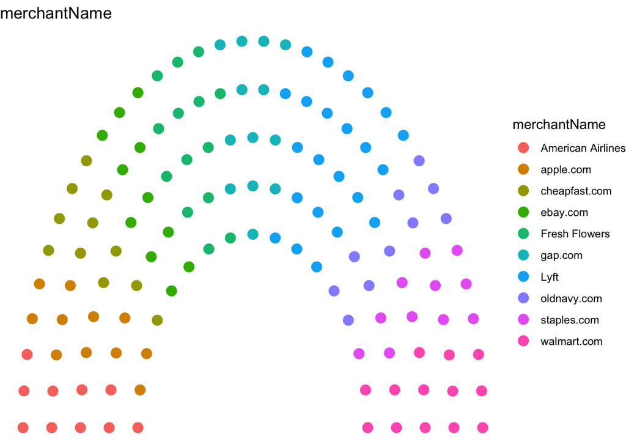

```r
ru_semicircle <- parliament_data(election_data = rev_fraud,
                                 type = "semicircle", # Parliament type
                                 parl_rows = 5,      # Number of rows of the parliament
                                 party_seats = rev_fraud$n) # Seats per party

ggplot(ru_semicircle, aes(x = x, y = y, colour = merchantName)) +
  geom_parliament_seats() +
  theme_ggparliament() +
  labs(title = "merchantName")
```

### Removing Outliers

- As we could see that data distribution was highly skewed in the numerical attributes, and it can drastically affect the model performance because fitting the line or plane would not be able to generalize well, so it is always useful to remove such outliers and have a better generalization and Test accuracy.

### Question:

### Method used to handle Outliers: Interquartile Ranges are generally used for removing the outliers in a numerical attribute

```r
{
  df <- df[df$creditLimit > quantile(df$creditLimit, .25) - 1.5*IQR(df$creditLimit) &
        df$creditLimit < quantile(df$creditLimit, .75) + 1.5*IQR(df$creditLimit), ]
  head(df, n = 5)
}
```

|  | accountNumber | customerId | creditLimit | availableMoney | transactionDateTime | transactionAmount | merchantName | acqCountry | merchantCountryCode | posEntryMode | posConditionCode | merchantCategoryCode | currentExpDate | accountOpenDate | dateOfLastAddressChange | cardCVV | enteredCVV | cardLast4Digits | transactionType | currentBalance | cardPresent | expirationDateKeyInMatch | isFraud |
| --- | --- | --- | --- | --- | --- | --- | --- | --- | --- | --- | --- | --- | --- | --- | --- | --- | --- | --- | --- | --- | --- | --- | --- |
| 1 | 737265056 | 737265056 | 5000 | 5000 | 2016-08-13T14:27:32 | 98.55 | Uber | US | US | 02 | 01 | rideshare | 06/2023 | 2015-03-14 | 2015-03-14 | 414 | 414 | 1803 | PURCHASE | 0 | 0 | 0 | 0 |
| 2 | 737265056 | 737265056 | 5000 | 5000 | 2016-10-11T05:05:54 | 74.51 | AMC #191138 | US | US | 09 | 01 | entertainment | 02/2024 | 2015-03-14 | 2015-03-14 | 486 | 486 | 767 | PURCHASE | 0 | 1 | 0 | 0 |
| 3 | 737265056 | 737265056 | 5000 | 5000 | 2016-11-08T09:18:39 | 7.47 | Play Store | US | US | 09 | 01 | mobileapps | 08/2025 | 2015-03-14 | 2015-03-14 | 486 | 486 | 767 | PURCHASE | 0 | 0 | 0 | 0 |
| 4 | 737265056 | 737265056 | 5000 | 5000 | 2016-12-10T02:14:50 | 7.47 | Play Store | US | US | 09 | 01 | mobileapps | 08/2025 | 2015-03-14 | 2015-03-14 | 486 | 486 | 767 | PURCHASE | 0 | 0 | 0 | 0 |
| 5 | 830329091 | 830329091 | 5000 | 5000 | 2016-03-24T21:04:46 | 71.18 | Tim Hortons #947751 | US | US | 02 | 01 | fastfood | 10/2029 | 2015-08-06 | 2015-08-06 | 885 | 885 | 3143 | PURCHASE | 0 | 1 | 0 | 0 |

- We can see which buckets are removed from the dataset. As for Models to generalize well on the dataset, it is advised to remove outliers. But in some use cases, we avoid that as well.

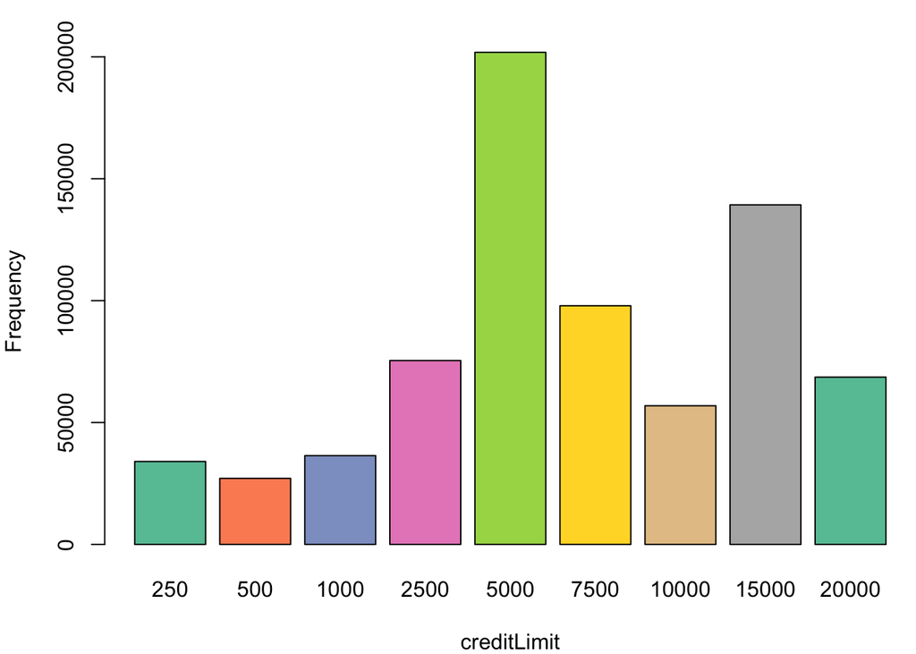

```r
library(RColorBrewer)
coul <- brewer.pal(8, "Set2")
e = count(df, creditLimit)
e <- e[complete.cases(e), ]
par(mar  = c(4, 4 ,2 ,0))
barplot(height= e$n, names= e$creditLimit, col=coul, xlab = 'creditLimit' , ylab = 'Frequency' )
```

### Data Visualization after handling outliers for better generalization.

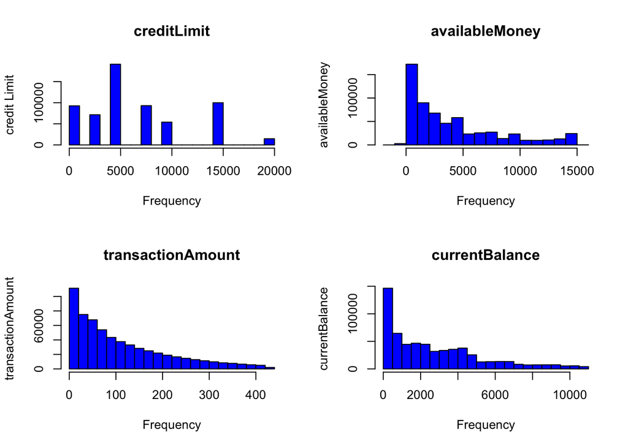

```r
df <- df[df$availableMoney > quantile(df$availableMoney, .25) - 1.5*IQR(df$availableMoney) &
        df$availableMoney < quantile(df$availableMoney, .75) + 1.5*IQR(df$availableMoney), ]
df <- df[df$transactionAmount > quantile(df$transactionAmount, .25) - 1.5*IQR(df$transactionAmount) &
        df$transactionAmount < quantile(df$transactionAmount, .75) + 1.5*IQR(df$transactionAmount), ]
df <- df[df$currentBalance > quantile(df$currentBalance, .25) - 1.5*IQR(df$currentBalance) &
        df$currentBalance < quantile(df$currentBalance, .75) + 1.5*IQR(df$currentBalance), ]
par(mfrow=c(2,2))
hist(df[ , c("creditLimit")], main="creditLimit", xlab="Frequency", ylab="credit Limit", col = "blue")
hist(df[ , c("availableMoney")], main="availableMoney", xlab="Frequency", ylab="availableMoney", col = "blue")
hist(df[ , c("transactionAmount")], main="transactionAmount", xlab="Frequency", ylab="transactionAmount", col = "blue")
hist(df[ , c("currentBalance")], main="currentBalance", xlab="Frequency", ylab="currentBalance", col = "blue")
```

### Box Plots are again drawn to help visualize how outliers were impacting the overall skewness.

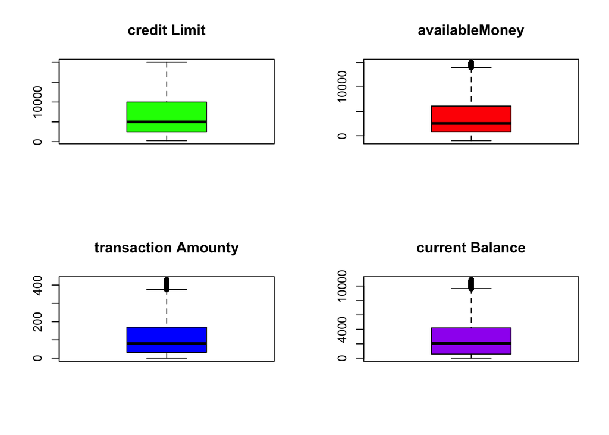

```r
par(mfrow=c(2,2))
boxplot(df[ , c("creditLimit")], col = "green", main="credit Limit")
boxplot(df[ , c("availableMoney")], col = "red", main="availableMoney")
boxplot(df[ , c("transactionAmount")], col = "blue", main="transaction Amounty")
boxplot(df[ , c("currentBalance")], col = "purple", main="current Balance")
```

# 4. Feature Engineering

- The reason for feature engineering is to make additional attributes from existing attributes that can be used effectively in the modeling and may enhance model predictions.

### Making an additional Column derived from the equality of CardCVV and EnteredCVV as shown

```r
df$CVVMatched <-  df$cardCVV == df$enteredCVV
```

### Transormation from Categorical and Booleans to Numerical

```r
df$CVVMatched <- as.integer(df$CVVMatched)
```

```r
dim(df)
```

```
## [1] 617105     24
```

### Making 4 set of values from time column: morning, afternoon/evening, night and late/mid night are also added as feature.

```r
df_time <- data.frame(df)
```

```r
head(df_time,n=5 )
```

|  | accountNumber | customerId | creditLimit | availableMoney | transactionDateTime | transactionAmount | merchantName | acqCountry | merchantCountryCode | posEntryMode | posConditionCode | merchantCategoryCode | currentExpDate | accountOpenDate | dateOfLastAddressChange | cardCVV | enteredCVV | cardLast4Digits | transactionType | currentBalance | cardPresent | expirationDateKeyInMatch | isFraud | CVVMatched |
| --- | --- | --- | --- | --- | --- | --- | --- | --- | --- | --- | --- | --- | --- | --- | --- | --- | --- | --- | --- | --- | --- | --- | --- | --- |
| 1 | 737265056 | 737265056 | 5000 | 5000 | 2016-08-13T14:27:32 | 98.55 | Uber | US | US | 02 | 01 | rideshare | 06/2023 | 2015-03-14 | 2015-03-14 | 414 | 414 | 1803 | PURCHASE | 0 | 0 | 0 | 0 | 1 |
| 2 | 737265056 | 737265056 | 5000 | 5000 | 2016-10-11T05:05:54 | 74.51 | AMC #191138 | US | US | 09 | 01 | entertainment | 02/2024 | 2015-03-14 | 2015-03-14 | 486 | 486 | 767 | PURCHASE | 0 | 1 | 0 | 0 | 1 |
| 3 | 737265056 | 737265056 | 5000 | 5000 | 2016-11-08T09:18:39 | 7.47 | Play Store | US | US | 09 | 01 | mobileapps | 08/2025 | 2015-03-14 | 2015-03-14 | 486 | 486 | 767 | PURCHASE | 0 | 0 | 0 | 0 | 1 |
| 4 | 737265056 | 737265056 | 5000 | 5000 | 2016-12-10T02:14:50 | 7.47 | Play Store | US | US | 09 | 01 | mobileapps | 08/2025 | 2015-03-14 | 2015-03-14 | 486 | 486 | 767 | PURCHASE | 0 | 0 | 0 | 0 | 1 |
| 5 | 830329091 | 830329091 | 5000 | 5000 | 2016-03-24T21:04:46 | 71.18 | Tim Hortons #947751 | US | US | 02 | 01 | fastfood | 10/2029 | 2015-08-06 | 2015-08-06 | 885 | 885 | 3143 | PURCHASE | 0 | 1 | 0 | 0 | 1 |

```r
library("lubridate")

df_time <- df_time %>%
  mutate(hour_admit = hour(strptime(transactionDateTime, format = "%Y-%m-%dT%H:%M:%S"))) %>%
  mutate(time_period = case_when(
    hour_admit > 05 & hour_admit < 11 ~ 0,
    hour_admit >= 11 & hour_admit < 17 ~ 1,
    hour_admit >= 17 & hour_admit < 23 ~ 2,
    hour_admit >=23 | hour_admit <= 5 ~ 3))
```

```r
df$transactionTimeCat = df_time$time_period
```

```r
head(df, n=5)
```

|  | accountNumber | customerId | creditLimit | availableMoney | transactionDateTime | transactionAmount | merchantName | acqCountry | merchantCountryCode | posEntryMode | posConditionCode | merchantCategoryCode | currentExpDate | accountOpenDate | dateOfLastAddressChange | cardCVV | enteredCVV | cardLast4Digits | transactionType | currentBalance | cardPresent | expirationDateKeyInMatch | isFraud | CVVMatched | transactionTimeCat |
| --- | --- | --- | --- | --- | --- | --- | --- | --- | --- | --- | --- | --- | --- | --- | --- | --- | --- | --- | --- | --- | --- | --- | --- | --- | --- |
| 1 | 737265056 | 737265056 | 5000 | 5000 | 2016-08-13T14:27:32 | 98.55 | Uber | US | US | 02 | 01 | rideshare | 06/2023 | 2015-03-14 | 2015-03-14 | 414 | 414 | 1803 | PURCHASE | 0 | 0 | 0 | 0 | 1 | 1 |
| 2 | 737265056 | 737265056 | 5000 | 5000 | 2016-10-11T05:05:54 | 74.51 | AMC #191138 | US | US | 09 | 01 | entertainment | 02/2024 | 2015-03-14 | 2015-03-14 | 486 | 486 | 767 | PURCHASE | 0 | 1 | 0 | 0 | 1 | 3 |
| 3 | 737265056 | 737265056 | 5000 | 5000 | 2016-11-08T09:18:39 | 7.47 | Play Store | US | US | 09 | 01 | mobileapps | 08/2025 | 2015-03-14 | 2015-03-14 | 486 | 486 | 767 | PURCHASE | 0 | 0 | 0 | 0 | 1 | 0 |
| 4 | 737265056 | 737265056 | 5000 | 5000 | 2016-12-10T02:14:50 | 7.47 | Play Store | US | US | 09 | 01 | mobileapps | 08/2025 | 2015-03-14 | 2015-03-14 | 486 | 486 | 767 | PURCHASE | 0 | 0 | 0 | 0 | 1 | 3 |
| 5 | 830329091 | 830329091 | 5000 | 5000 | 2016-03-24T21:04:46 | 71.18 | Tim Hortons #947751 | US | US | 02 | 01 | fastfood | 10/2029 | 2015-08-06 | 2015-08-06 | 885 | 885 | 3143 | PURCHASE | 0 | 1 | 0 | 0 | 1 | 2 |

### No of Transaction based on Four timing range

```r
count(df, transactionTimeCat)
```

| transactionTimeCat | n |
| --- | --- |
| 0 | 128254 |
| 1 | 154273 |
| 2 | 154956 |
| 3 | 179622 |

### Count of CVV Matched and not mached

```r
count(df, CVVMatched)
```

| CVVMatched | n |
| --- | --- |
| 0 | 5560 |
| 1 | 611545 |

### Here we are removing the attributes which are unique identifiers like Customer IDs, Account IDs etc.

- As these attributes are not useful for learning patterns, these are just present for uniquely identifying the rows in the database.
- Also, we have made additional feature columns from the Date Time so, the basic time attribute is not needed anymore, so removing that as well to make the model generalizable.
- Other similar unique identifiers are removed for the same reason.

```r
drops <- c('accountNumber','customerId', 'transactionDateTime', 'cardLast4Digits', 'cardCVV', 'enteredCVV', 'accountOpenDate', 'dateOfLastAddressChange', 'currentExpDate')
df <- df[ , !(names(df) %in% drops)]
print('Final total columns')
```

```
## [1] "Final total columns"
```

```r
ncol(df)
```

```
## [1] 16
```

### Categorical to Numerical Fitting through LabelEncoder

```r
library(superml)

le <- LabelEncoder$new()

columns <- c('merchantName', 'acqCountry', 'merchantCountryCode', 'merchantCategoryCode', 'transactionType', 'posEntryMode', 'posConditionCode')

label <- LabelEncoder$new()
df$merchantName <- label$fit_transform(df$merchantName)

df$acqCountry <- label$fit_transform(df$acqCountry)

df$merchantCountryCode <- label$fit_transform(df$merchantCountryCode)

df$merchantCategoryCode <- label$fit_transform(df$merchantCategoryCode)

df$transactionType <- label$fit_transform(df$transactionType)

df$posEntryMode <- label$fit_transform(df$posEntryMode)

df$posConditionCode <- label$fit_transform(df$posConditionCode)
```

```r
df = df %>%
   mutate_all(~ifelse(is.na(.), mode(., na.rm = TRUE), .))
```

# 5. Handling Imbalance of Data Set

### As the Data is Imbalanced, so to run classification models efficiently it is advised to use a Down or Upper Sampling technique to balance the dataset for better results

```r
#install.packages(c("zoo","xts","quantmod"))
#install.packages("smotefamily")
```

### Using OverSampling Technique

- The ROSE provides functions to deal with binary classification problems in the presence of imbalanced classes. Artificial balanced samples are generated according to a smoothed bootstrap approach and allow for aiding both the phases of estimation and accuracy evaluation of a binary classifier in the presence of a rare class. Functions that implement more traditional remedies for the class imbalance and different metrics to evaluate accuracy are also provided. These are estimated by holdout, bootstrap, or cross-validation methods.

```r
library(DMwR2) # for smote implementation
library(ROSE)# for ROSE sampling

# smote
set.seed(9560)
rose_train <- ROSE(isFraud ~ ., data  = df)$data
```

```r
table(rose_train$isFraud)
```

```
##
##      0      1
## 309174 307931
```

### Using UnderSampling Technique

- Ovun creates possibly balanced samples by random over-sampling minority examples, under-sampling majority examples or combination of over- and under-sampling.

```r
under_v1 <- ovun.sample(isFraud ~ .,
                        data = df,
                        method = "under",
                        N = 2 * sum(df$isFraud == 1))
```

```r
df_under = under_v1$data
```

```r
table(df_under$isFraud)
```

```
##
##    0    1
## 8847 8847
```

# 6. Modeling:

### For Model Evaluation Always Train the model on Training dataset and Verify on test data sets.

# Baseline: Logistic Regression

- In logistic regression, we decide a probability threshold. If the probability of a particular element is higher than the probability threshold then we classify that element in one group or vice versa.
- Logistic Regression model can be used as a baseline classifier and it is really a robust model to compare with. It is always advised to start with simpler models and then keep on adding complexity to have a clear trade-off between Variance and Bias.

```r
# Libraries
library(pROC, quietly=TRUE)
library(microbenchmark, quietly=TRUE)

# Set seed so the train/test split is reproducible

# Loading package
library(caTools)
library(ROCR)

ds_noads = df_under


#split <- sample.split(ds_noads, SplitRatio = 0.7)


#train <- subset(ds_noads, split == "TRUE")
#test <- subset(ds_noads, split == "FALSE")

#create a list of random number ranging from 1 to number of rows from actual data

#and 70% of the data into training data


data2 = sort(sample(nrow(ds_noads), nrow(ds_noads)*.8))


#creating training data set by selecting the output row values

train <- ds_noads[data2,]


#creating test data set by not selecting the output row values

test <- ds_noads[-data2,]

# Training model
logistic_model <- glm(isFraud ~ .,
                      data = train,
                      family = "binomial")

#logistic_model

# Summary
summary(logistic_model)
```

```
##
## Call:
## glm(formula = isFraud ~ ., family = "binomial", data = train)
##
## Deviance Residuals:
##     Min       1Q   Median       3Q      Max
## -2.0817  -1.0694  -0.5585   1.0963   2.0292
##
## Coefficients: (1 not defined because of singularities)
##                              Estimate   Std. Error z value
## (Intercept)               0.203188709  0.168595143   1.205
## creditLimit               0.000011916  0.000006803   1.752
## availableMoney           -0.000012060  0.000008381  -1.439
## transactionAmount         0.004758081  0.000169930  28.000
## merchantName             -0.000465575  0.000041221 -11.295
## acqCountry                0.043301686  0.228171315   0.190
## merchantCountryCode       0.084819309  0.233430307   0.363
## posEntryMode             -0.113553464  0.017284093  -6.570
## posConditionCode         -0.075115314  0.039741254  -1.890
## merchantCategoryCode      0.006528148  0.004391111   1.487
## transactionType          -0.027811227  0.050030075  -0.556
## currentBalance                     NA           NA      NA
## cardPresent              -0.420620035  0.041709599 -10.084
## expirationDateKeyInMatch  0.795534257  0.514831351   1.545
## CVVMatched               -0.433319209  0.159294140  -2.720
## transactionTimeCat       -0.014773995  0.015988819  -0.924
##                                      Pr(>|z|)
## (Intercept)                           0.22813
## creditLimit                           0.07984 .
## availableMoney                        0.15017
## transactionAmount        < 0.0000000000000002 ***
## merchantName             < 0.0000000000000002 ***
## acqCountry                            0.84948
## merchantCountryCode                   0.71634
## posEntryMode                  0.0000000000504 ***
## posConditionCode                      0.05874 .
## merchantCategoryCode                  0.13710
## transactionType                       0.57829
## currentBalance                             NA
## cardPresent              < 0.0000000000000002 ***
## expirationDateKeyInMatch              0.12229
## CVVMatched                            0.00652 **
## transactionTimeCat                    0.35548
## ---
## Signif. codes:
## 0 '***' 0.001 '**' 0.01 '*' 0.05 '.' 0.1 ' ' 1
##
## (Dispersion parameter for binomial family taken to be 1)
##
##     Null deviance: 19623  on 14154  degrees of freedom
## Residual deviance: 18139  on 14140  degrees of freedom
## AIC: 18169
##
## Number of Fisher Scoring iterations: 4
```

### Dimentions of Train data

```r
dim(train)
```

```
## [1] 14155    16
```

### Dimentions of Test data

```r
dim(test)
```

```
## [1] 3539   16
```

```r
predict_reg <- predict(logistic_model,
                       test, type = "response")
#predict_reg

# Changing probabilities
predict_reg <- ifelse(predict_reg >0.5, 1, 0)

# Evaluating model accuracy
# using confusion matrix
table(test$isFraud, predict_reg)
```

```
##    predict_reg
##        0    1
##   0 1209  547
##   1  680 1103
```

```r
missing_classerr <- mean(predict_reg != test$isFraud)
print(paste('Accuracy =', 1 - missing_classerr))
```

```
## [1] "Accuracy = 0.65329189036451"
```

```r
as.data.frame(table(ds_noads$isFraud))
```

| Var1 | Freq |
| --- | --- |
| 0 | 8847 |
| 1 | 8847 |

```r
ROCPred <- prediction(predict_reg, test$isFraud)
ROCPer <- performance(ROCPred, measure = "tpr",
                      x.measure = "fpr")

auc <- performance(ROCPred, measure = "auc")
auc <- auc@y.values[[1]]
auc
```

```
## [1] 0.6535584
```

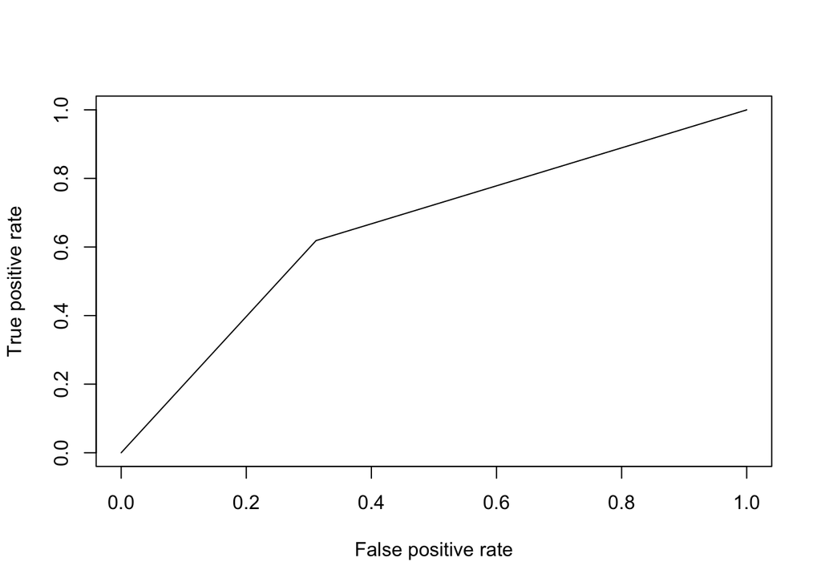

```r
# Plotting curve
plot(ROCPer)
```

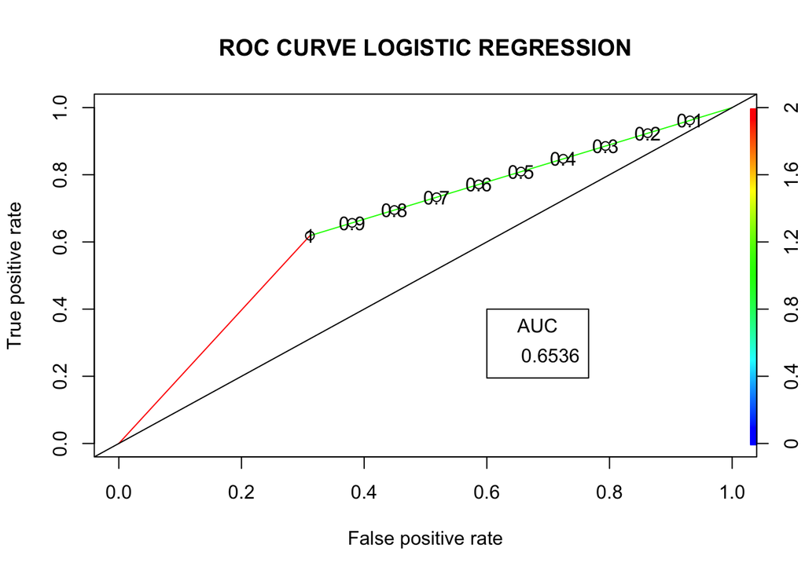

```r
plot(ROCPer, colorize = TRUE,
     print.cutoffs.at = seq(0.1, by = 0.1),
     main = "ROC CURVE LOGISTIC REGRESSION")
abline(a = 0, b = 1)

auc <- round(auc, 4)
legend(.6, .4, auc, title = "AUC", cex = 1)
```

```r
library(e1071)

library(caret)

confusionMatrix(factor(predict_reg), factor(test$isFraud))
```

```
## Confusion Matrix and Statistics
##
##           Reference
## Prediction    0    1
##          0 1209  680
##          1  547 1103
##
##                Accuracy : 0.6533
##                  95% CI : (0.6373, 0.669)
##     No Information Rate : 0.5038
##     P-Value [Acc > NIR] : < 0.00000000000000022
##
##                   Kappa : 0.3069
##
##  Mcnemar's Test P-Value : 0.0001643
##
##             Sensitivity : 0.6885
##             Specificity : 0.6186
##          Pos Pred Value : 0.6400
##          Neg Pred Value : 0.6685
##              Prevalence : 0.4962
##          Detection Rate : 0.3416
##    Detection Prevalence : 0.5338
##       Balanced Accuracy : 0.6536
##
##        'Positive' Class : 0
##
```

```r
confusionMatrix(factor(predict_reg), factor(test$isFraud), mode = "everything", positive="1")
```

```
## Confusion Matrix and Statistics
##
##           Reference
## Prediction    0    1
##          0 1209  680
##          1  547 1103
##
##                Accuracy : 0.6533
##                  95% CI : (0.6373, 0.669)
##     No Information Rate : 0.5038
##     P-Value [Acc > NIR] : < 0.00000000000000022
##
##                   Kappa : 0.3069
##
##  Mcnemar's Test P-Value : 0.0001643
##
##             Sensitivity : 0.6186
##             Specificity : 0.6885
##          Pos Pred Value : 0.6685
##          Neg Pred Value : 0.6400
##               Precision : 0.6685
##                  Recall : 0.6186
##                      F1 : 0.6426
##              Prevalence : 0.5038
##          Detection Rate : 0.3117
##    Detection Prevalence : 0.4662
##       Balanced Accuracy : 0.6536
##
##        'Positive' Class : 1
##
```

### The Results of Logisitc Regression Classifier:

### Accuracy = 0.6535 = 65.35%

- Here, it can be seen that the logistic regression model tried to draw the boundary between the fraud and non-fraud data set and could perform with 65% of accuracy on the given attributes. Here, the problem is inherently challenging as the real-world transaction data-set may have 100 and 1000s of predictive attributes (and it is not a synthetic data set, so it is an expected result on a real-day dataset), and on the given attributes 65% is still a significant number with a great precision and recall ratio.

# Alternative Basline: K-Nearest Neighbor

- KNN tries to predict the correct class for the test data by calculating the distance between the test data and all the specified training points. Then select the K number of points which is closet to the test data. The KNN algorithm calculates the probability of the test data belonging to the classes of ‘K’ training data and class holds the highest probability will be selected.

```r
fitControl <- trainControl(method="cv",
                            number = 5,
                            preProcOptions = list(thresh = 0.99), # threshold for pca preprocess
                            classProbs = TRUE,
                            summaryFunction = twoClassSummary)

train$isFraud <- factor(train$isFraud)

model_knn <- train(make.names(isFraud)~.,
                   train,
                   method="knn",
                   metric="ROC",
                   preProcess = c('center', 'scale'),
                   tuneLength=10,
                   trControl=fitControl)
```

```r
pred_knn <- predict(model_knn, test)

ROCPred <- prediction(as.numeric(pred_knn), test$isFraud)
ROCPer <- performance(ROCPred, measure = "tpr",
                      x.measure = "fpr")

auc <- performance(ROCPred, measure = "auc")
auc <- auc@y.values[[1]]
auc
```

```
## [1] 0.6590938
```

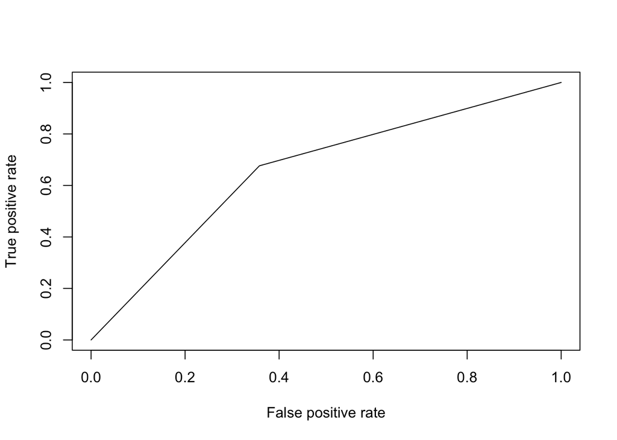

```r
# Plotting curve
plot(ROCPer)
```

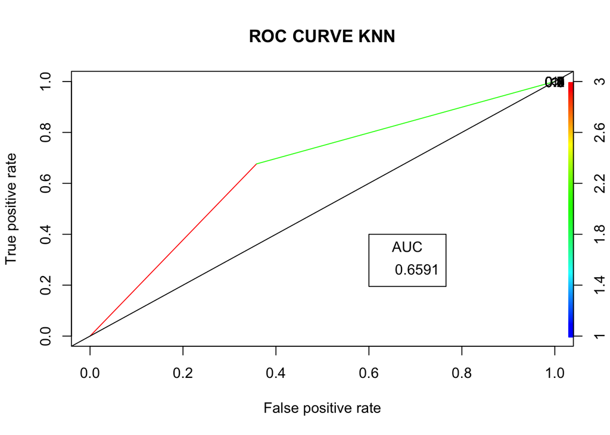

```r
plot(ROCPer, colorize = TRUE,
     print.cutoffs.at = seq(0.1, by = 0.1),
     main = "ROC CURVE KNN")
abline(a = 0, b = 1)

auc <- round(auc, 4)
legend(.6, .4, auc, title = "AUC", cex = 1)
```

### The Results of K nearest neighbour:

- The result is very much comparable to the Logistic regression technique. So, it can clearly be seen that we need to add more variance in the model, which we are going to do through Tree-based models. The simple reason is that to still have the interpretability from a business point of view that which features carry more predictiveness and help in decision making.

# Tree-Based Classifiers for better Accuracy and Interpretability

# Decision Tree to identify important predictive features to enhance the variance of the model.

- A decision tree is drawn upside down with its root at the top. It starts with a condition/internal node, based on which the tree splits into branches/ edges. The end of the branch that doesn’t split anymore is the decision/leaf, in this case, whether the fraud happens or not, respectively. Inherently it can be seen that it explains which features are important and can help in decision-making with its hierarchical structure.

### The decision tree provides us with the interpretability regarding the decision made over the feature set, which may lead to good accuracy and shows a clear hierarchy

```r
raw.data = df_under


nrows <- nrow(raw.data)
set.seed(314)
indexT <- sample(1:nrow(raw.data), 0.8 * nrows)
#separate train and validation set
trainset = raw.data[indexT,]
verset =   raw.data[-indexT,]

train = trainset
test = verset

library(rpart) # for regression trees
library(randomForest) # for random forests


# train a decision tree based on our dataset
tree.model <- rpart(isFraud ~ ., data = train)
```

### Decison Tree developed over dataset

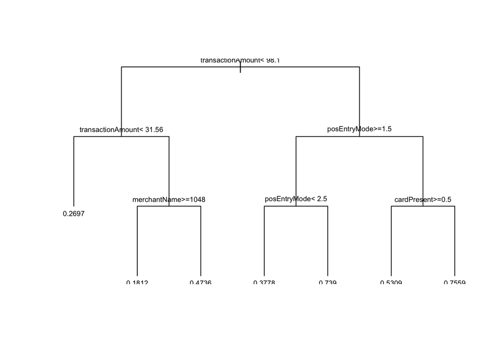

```r
# plot our regression tree
plot(tree.model, uniform=TRUE)
# add text labels & make them 60% as big as they are by default
text(tree.model, cex=.6)
```

- The decision tree clearly shows how important the transaction amount is, then the predictive power of posEntryMode and later on, if the card is present or not, has a high impact on the response variable “isFraud”.

# Ensemble: Random Forest for Feature Importance as it is more robust than a decision tree, and does not easily overfit.

- Random forest consists of a large number of individual decision trees that operate as an ensemble. Each individual tree in the random forest spits out a class prediction and the class with the most votes becomes our model’s prediction. A large number of relatively uncorrelated models (trees) operating as a committee will outperform any of the individual constituent models.

### It provides the feature importance with the help of Gini index and Information Gain, which helps in determining which feature influence more on the fradulent transactions.

```r
raw.data = df_under


nrows <- nrow(raw.data)
set.seed(314)
indexT <- sample(1:nrow(raw.data), 0.8 * nrows)
#separate train and validation set
trainset = raw.data[indexT,]
verset =   raw.data[-indexT,]
n <- names(trainset)
rf.form <- as.formula(paste("isFraud ~", paste(n[!n %in% "isFraud"], collapse = " + ")))
trainset.rf <- randomForest(rf.form,trainset,ntree=100,importance=T)
```

### Plots showing feature importance

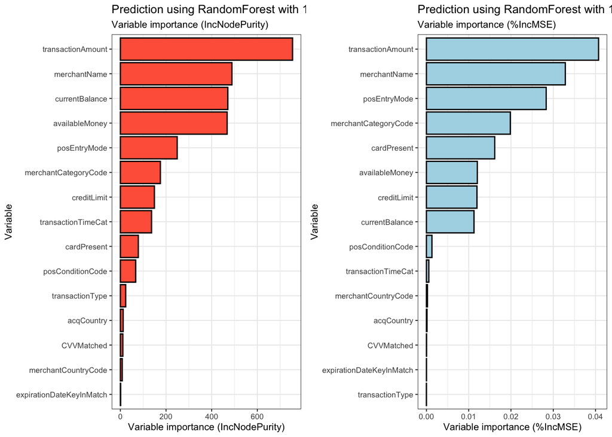

```r
varimp <- data.frame(trainset.rf$importance)
  vi1 <- ggplot(varimp, aes(x=reorder(rownames(varimp),IncNodePurity), y=IncNodePurity)) +
  geom_bar(stat="identity", fill="tomato", colour="black") +
  coord_flip() + theme_bw(base_size = 8) +
  labs(title="Prediction using RandomForest with 100 trees", subtitle="Variable importance (IncNodePurity)", x="Variable", y="Variable importance (IncNodePurity)")

  vi2 <- ggplot(varimp, aes(x=reorder(rownames(varimp),X.IncMSE), y=X.IncMSE)) +
  geom_bar(stat="identity", fill="lightblue", colour="black") +
  coord_flip() + theme_bw(base_size = 8) +
  labs(title="Prediction using RandomForest with 100 trees", subtitle="Variable importance (%IncMSE)", x="Variable", y="Variable importance (%IncMSE)")


library(gridExtra)
library(grid)
library(ggplot2)
library(lattice)

grid.arrange(vi1, vi2, ncol=2)
```

- Random Forest clearly identifies important features with high impact, the Top 5 are:
- Transaction Amount
- Merchant Name
- Current Balance
- Available Money
- POS Entry Mode and others will go inside the final model.